# Explore_bikeshare_data

### Explore Bike Share Data

For this project, your goal is to ask and answer three questions about the available bikeshare data from Washington, Chicago, and New York. This notebook can be submitted directly through the workspace when you are confident in your results.

You will be graded against the project [Rubric](https://review.udacity.com/#!/rubrics/2508/view) by a mentor after you have submitted. To get you started, you can use the template below, but feel free to be creative in your solutions!

**Introduction**

This project analyzes bike-share data from New York City, Chicago, and Washington, D.C. The goal is to answer three questions using the available data by importing, exploring, and visualizing the datasets with R. The analysis focuses on usage patterns, popular bike share stations, and user types to identify similarities and differences among the three cities.

```r
ny = read.csv('new_york_city.csv')
wash = read.csv('washington.csv')
chi = read.csv('chicago.csv')
```

```r
head(ny)
```

| X | Start.Time | End.Time | Trip.Duration | Start.Station | End.Station | User.Type | Gender | Birth.Year |
| --- | --- | --- | --- | --- | --- | --- | --- | --- |
| 5688089 | 2017-06-11 14:55:05 | 2017-06-11 15:08:21 | 795 | Suffolk St & Stanton St | W Broadway & Spring St | Subscriber | Male | 1998 |
| 4096714 | 2017-05-11 15:30:11 | 2017-05-11 15:41:43 | 692 | Lexington Ave & E 63 St | 1 Ave & E 78 St | Subscriber | Male | 1981 |
| 2173887 | 2017-03-29 13:26:26 | 2017-03-29 13:48:31 | 1325 | 1 Pl & Clinton St | Henry St & Degraw St | Subscriber | Male | 1987 |
| 3945638 | 2017-05-08 19:47:18 | 2017-05-08 19:59:01 | 703 | Barrow St & Hudson St | W 20 St & 8 Ave | Subscriber | Female | 1986 |
| 6208972 | 2017-06-21 07:49:16 | 2017-06-21 07:54:46 | 329 | 1 Ave & E 44 St | E 53 St & 3 Ave | Subscriber | Male | 1992 |
| 1285652 | 2017-02-22 18:55:24 | 2017-02-22 19:12:03 | 998 | State St & Smith St | Bond St & Fulton St | Subscriber | Male | 1986 |

```r
head(wash)
```

| X | Start.Time | End.Time | Trip.Duration | Start.Station | End.Station | User.Type |
| --- | --- | --- | --- | --- | --- | --- |
| 1621326 | 2017-06-21 08:36:34 | 2017-06-21 08:44:43 | 489.066 | 14th & Belmont St NW | 15th & K St NW | Subscriber |
| 482740 | 2017-03-11 10:40:00 | 2017-03-11 10:46:00 | 402.549 | Yuma St & Tenley Circle NW | Connecticut Ave & Yuma St NW | Subscriber |
| 1330037 | 2017-05-30 01:02:59 | 2017-05-30 01:13:37 | 637.251 | 17th St & Massachusetts Ave NW | 5th & K St NW | Subscriber |
| 665458 | 2017-04-02 07:48:35 | 2017-04-02 08:19:03 | 1827.341 | Constitution Ave & 2nd St NW/DOL | M St & Pennsylvania Ave NW | Customer |
| 1481135 | 2017-06-10 08:36:28 | 2017-06-10 09:02:17 | 1549.427 | Henry Bacon Dr & Lincoln Memorial Circle NW | Maine Ave & 7th St SW | Subscriber |
| 1148202 | 2017-05-14 07:18:18 | 2017-05-14 07:24:56 | 398.000 | 1st & K St SE | Eastern Market Metro / Pennsylvania Ave & 7th St SE | Subscriber |

```r
head(chi)
```

| X | Start.Time | End.Time | Trip.Duration | Start.Station | End.Station | User.Type | Gender | Birth.Year |
| --- | --- | --- | --- | --- | --- | --- | --- | --- |
| 1423854 | 2017-06-23 15:09:32 | 2017-06-23 15:14:53 | 321 | Wood St & Hubbard St | Damen Ave & Chicago Ave | Subscriber | Male | 1992 |
| 955915 | 2017-05-25 18:19:03 | 2017-05-25 18:45:53 | 1610 | Theater on the Lake | Sheffield Ave & Waveland Ave | Subscriber | Female | 1992 |
| 9031 | 2017-01-04 08:27:49 | 2017-01-04 08:34:45 | 416 | May St & Taylor St | Wood St & Taylor St | Subscriber | Male | 1981 |
| 304487 | 2017-03-06 13:49:38 | 2017-03-06 13:55:28 | 350 | Christiana Ave & Lawrence Ave | St. Louis Ave & Balmoral Ave | Subscriber | Male | 1986 |
| 45207 | 2017-01-17 14:53:07 | 2017-01-17 15:02:01 | 534 | Clark St & Randolph St | Desplaines St & Jackson Blvd | Subscriber | Male | 1975 |
| 1473887 | 2017-06-26 09:01:20 | 2017-06-26 09:11:06 | 586 | Clinton St & Washington Blvd | Canal St & Taylor St | Subscriber | Male | 1990 |

### Question 1

When are bike share systems used most frequently across the three cities

```r
# Function to prepare each city's data
prepare_data <- function(df, city_name) {
    df$Start.Time <- as.POSIXct(
        df$Start.Time,
        format = "%Y-%m-%d %H:%M:%S"
    )

    df$Month <- format(df$Start.Time, "%B")
    df$DayOfWeek <- format(df$Start.Time, "%A")
    df$Hour <- as.numeric(format(df$Start.Time, "%H"))
    df$City <- city_name

    return(df)
}

# Prepare all three datasets
chi <- prepare_data(chi, "Chicago")
ny <- prepare_data(ny, "New York City")
wash <- prepare_data(wash, "Washington")
```

```r
# Combine the three cities
time_data <- rbind(
    chi[, c("Month", "DayOfWeek", "Hour", "City")],
    ny[, c("Month", "DayOfWeek", "Hour", "City")],
    wash[, c("Month", "DayOfWeek", "Hour", "City")]
)
```

```r
# Find the busiest month for each city
month_counts <- aggregate(
    list(Rides = time_data$Month),
    by = list(City = time_data$City, Month = time_data$Month),
    FUN = length
)

month_counts <- month_counts[
    order(month_counts$City, -month_counts$Rides),
]

busiest_months <- do.call(
    rbind,
    lapply(split(month_counts, month_counts$City), head, 1)
)

busiest_months
```

|  | City | Month | Rides |
| --- | --- | --- | --- |
| Chicago | Chicago | June | 2816 |
| New York City | New York City | June | 14000 |
| Washington | Washington | June | 20335 |

```r
# Find the busiest day for each city
day_counts <- aggregate(
    list(Rides = time_data$DayOfWeek),
    by = list(City = time_data$City, Day = time_data$DayOfWeek),
    FUN = length
)

day_counts <- day_counts[
    order(day_counts$City, -day_counts$Rides),
]

busiest_days <- do.call(
    rbind,
    lapply(split(day_counts, day_counts$City), head, 1)
)

busiest_days
```

|  | City | Day | Rides |
| --- | --- | --- | --- |
| Chicago | Chicago | Monday | 1302 |
| New York City | New York City | Wednesday | 9632 |
| Washington | Washington | Wednesday | 14212 |

```r
# Find the busiest hour for each city
hour_counts <- aggregate(
    list(Rides = time_data$Hour),
    by = list(City = time_data$City, Hour = time_data$Hour),
    FUN = length
)

hour_counts <- hour_counts[
    order(hour_counts$City, -hour_counts$Rides),
]

busiest_hours <- do.call(
    rbind,
    lapply(split(hour_counts, hour_counts$City), head, 1)
)

busiest_hours
```

|  | City | Hour | Rides |
| --- | --- | --- | --- |
| Chicago | Chicago | 17 | 1039 |
| New York City | New York City | 17 | 5503 |
| Washington | Washington | 8 | 9805 |

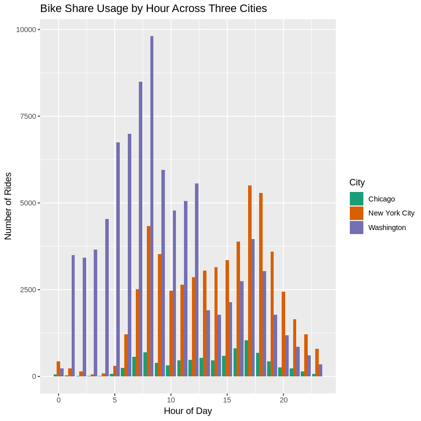

```r
library(ggplot2)

ggplot(hour_counts, aes(x = Hour, y = Rides, fill = City)) +
    geom_col(position = "dodge") +
    labs(
        title = "Bike Share Usage by Hour Across Three Cities",
        x = "Hour of Day",
        y = "Number of Rides",
        fill = "City"
    ) +
    scale_fill_manual(values = c(
    "Chicago" = "#1b9e77",
    "New York City" = "#d95f02",
    "Washington" = "#7570b3"
))
```

### Question 2

```r
# Function to find the most common start stations
get_top_stations <- function(df, city_name, n = 10) {
    station_counts <- as.data.frame(
        sort(table(df$Start.Station), decreasing = TRUE)
    )

    names(station_counts) <- c("Station", "Rides")
    station_counts$City <- city_name

    head(station_counts, n)
}

# Find the top 10 start stations in each city
top_chicago <- get_top_stations(chi, "Chicago")
top_new_york <- get_top_stations(ny, "New York City")
top_washington <- get_top_stations(wash, "Washington")

top_stations <- rbind(
    top_chicago,
    top_new_york,
    top_washington
)

top_stations
```

| Station | Rides | City |
| --- | --- | --- |
| Streeter Dr & Grand Ave | 210 | Chicago |
| Lake Shore Dr & Monroe St | 140 | Chicago |
| Clinton St & Washington Blvd | 120 | Chicago |
| Clinton St & Madison St | 102 | Chicago |
| Canal St & Adams St | 101 | Chicago |
| Michigan Ave & Oak St | 98 | Chicago |
| Canal St & Madison St | 87 | Chicago |
| Columbus Dr & Randolph St | 85 | Chicago |
| Lake Shore Dr & North Blvd | 85 | Chicago |
| Franklin St & Monroe St | 81 | Chicago |
| Pershing Square North | 592 | New York City |
| W 21 St & 6 Ave | 385 | New York City |
| Broadway & E 22 St | 383 | New York City |
| E 17 St & Broadway | 380 | New York City |
| West St & Chambers St | 364 | New York City |
| W 20 St & 11 Ave | 329 | New York City |
| 8 Ave & W 31 St | 316 | New York City |
| 8 Ave & W 33 St | 302 | New York City |
| W 41 St & 8 Ave | 292 | New York City |
| Greenwich Ave & 8 Ave | 288 | New York City |
| Columbus Circle / Union Station | 1700 | Washington |
| Lincoln Memorial | 1546 | Washington |
| Jefferson Dr & 14th St SW | 1488 | Washington |
| Massachusetts Ave & Dupont Circle NW | 1219 | Washington |
| Jefferson Memorial | 1068 | Washington |
| 15th & P St NW | 1040 | Washington |
| Smithsonian-National Mall / Jefferson Dr & 12th St SW | 1010 | Washington |
| Henry Bacon Dr & Lincoln Memorial Circle NW | 910 | Washington |
| 4th St & Madison Dr NW | 894 | Washington |
| Eastern Market Metro / Pennsylvania Ave & 7th St SE | 823 | Washington |

```r
# Find the single busiest start station in each city
busiest_stations <- do.call(
    rbind,
    lapply(split(top_stations, top_stations$City), head, 1)
)

busiest_stations
```

|  | Station | Rides | City |
| --- | --- | --- | --- |
| Chicago | Streeter Dr & Grand Ave | 210 | Chicago |
| New York City | Pershing Square North | 592 | New York City |
| Washington | Columbus Circle / Union Station | 1700 | Washington |

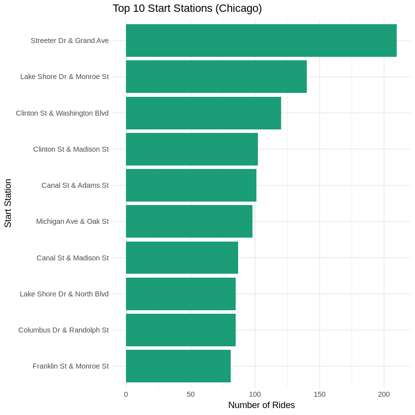

```r
# Chicago top start stations
ggplot(
    top_chicago,
    aes(x = reorder(Station, Rides), y = Rides)
) +
    geom_col(fill = "#1b9e77") +
    coord_flip() +
    labs(
        title = "Top 10 Start Stations (Chicago)",
        x = "Start Station",
        y = "Number of Rides"
    ) +
    theme_minimal()
```

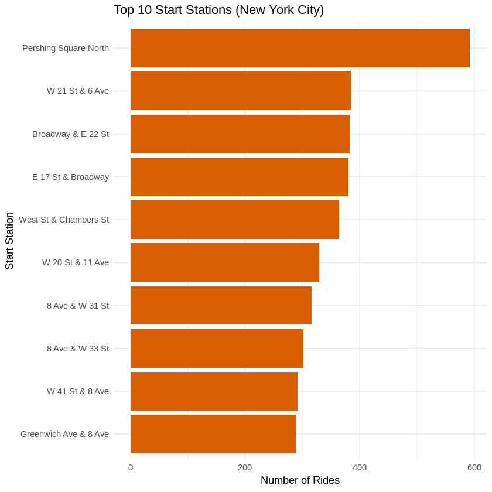

```r
# New York City top start stations
ggplot(
    top_new_york,
    aes(x = reorder(Station, Rides), y = Rides)
) +
    geom_col(fill = "#d95f02") +
    coord_flip() +
    labs(
        title = "Top 10 Start Stations (New York City)",
        x = "Start Station",
        y = "Number of Rides"
    ) +
    theme_minimal()
```

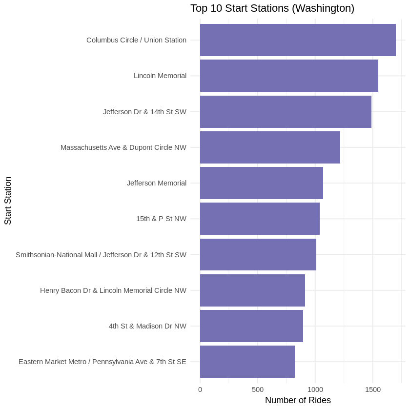

```r
# Washington top start stations
ggplot(
    top_washington,
    aes(x = reorder(Station, Rides), y = Rides)
) +
    geom_col(fill = "#7570b3") +
    coord_flip() +
    labs(
        title = "Top 10 Start Stations (Washington)",
        x = "Start Station",
        y = "Number of Rides"
    ) +
    theme_minimal()
```

### Question 3

How do bike share user types differ among Chicago, New York City, and Washington, D.C.?

```r
# Count user types for each city
user_types <- rbind(
    data.frame(City = "Chicago",
               User.Type = names(table(chi$User.Type)),
               Count = as.numeric(table(chi$User.Type))),

    data.frame(City = "New York City",
               User.Type = names(table(ny$User.Type)),
               Count = as.numeric(table(ny$User.Type))),

    data.frame(City = "Washington",
               User.Type = names(table(wash$User.Type)),
               Count = as.numeric(table(wash$User.Type)))
)

user_types
```

| City | User.Type | Count |
| --- | --- | --- |
| Chicago |  | 1 |
| Chicago | Customer | 1746 |
| Chicago | Subscriber | 6883 |
| New York City |  | 119 |
| New York City | Customer | 5558 |
| New York City | Subscriber | 49093 |
| Washington |  | 1 |
| Washington | Customer | 23450 |
| Washington | Subscriber | 65600 |

```r
# Display summary counts
aggregate(
    Count ~ City + User.Type,
    data = user_types,
    sum
)
```

| City | User.Type | Count |
| --- | --- | --- |
| Chicago |  | 1 |
| New York City |  | 119 |
| Washington |  | 1 |
| Chicago | Customer | 1746 |
| New York City | Customer | 5558 |
| Washington | Customer | 23450 |
| Chicago | Subscriber | 6883 |
| New York City | Subscriber | 49093 |
| Washington | Subscriber | 65600 |

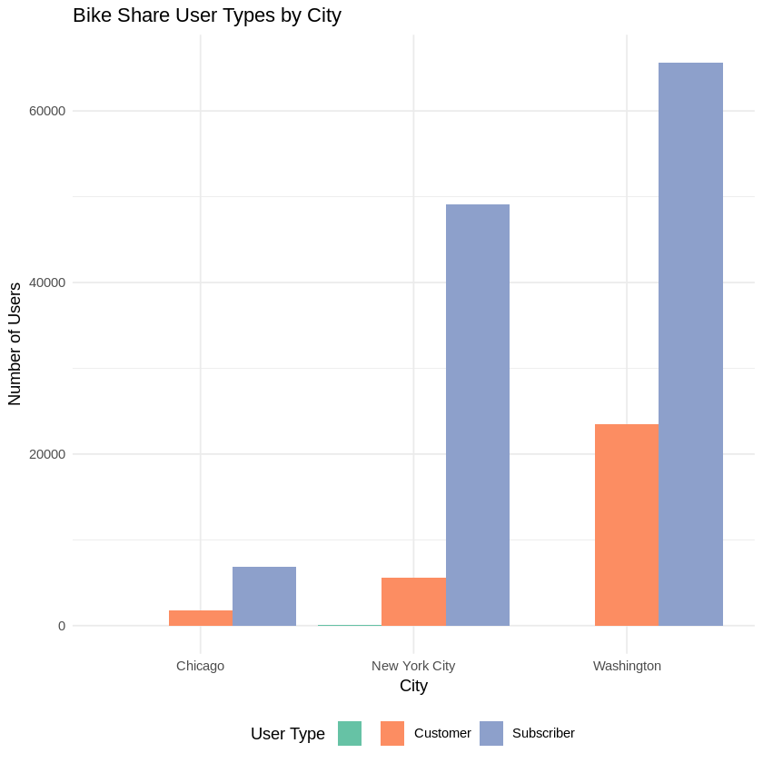

```r
library(ggplot2)

ggplot(user_types,
       aes(x = City,
           y = Count,
           fill = User.Type)) +
    geom_col(position = "dodge") +
    labs(
        title = "Bike Share User Types by City",
        x = "City",
        y = "Number of Users",
        fill = "User Type"
    ) +
    scale_fill_brewer(palette = "Set2") +
    theme_minimal() +
    theme(
        legend.position = "bottom"
    )
```

The comparison of user types showed that subscribers made up the majority of bike share users in all three cities. Washington recorded the largest number of both subscribers and customers, followed by New York City and Chicago. In each city, subscriber memberships greatly outnumbered customer rides, suggesting that many users rely on the bike share system for regular transportation rather than occasional use. These results indicate that recurring memberships play an important role in supporting bike share programs across the three cities.

## Finishing Up

> Congratulations! You have reached the end of the Explore Bikeshare Data Project. You should be very proud of all you have accomplished!

> **Tip**: Once you are satisfied with your work here, check over your report to make sure that it is satisfies all the areas of the [rubric](https://review.udacity.com/#!/rubrics/2508/view).

## Directions to Submit

> Before you submit your project, you need to create a .html or .pdf version of this notebook in the workspace here. To do that, run the code cell below. If it worked correctly, you should get a return code of 0, and you should see the generated .html file in the workspace directory (click on the orange Jupyter icon in the upper left).

> Alternatively, you can download this report as .html via the **File** > **Download as** submenu, and then manually upload it into the workspace directory by clicking on the orange Jupyter icon in the upper left, then using the Upload button.

> Once you've done this, you can submit your project by clicking on the "Submit Project" button in the lower right here. This will create and submit a zip file with this .ipynb doc and the .html or .pdf version you created. Congratulations!

```r
system('python -m nbconvert Explore_bikeshare_data.ipynb')
```